# R Crash Course

Mark Dunning

Last modified: 07 Oct 2020

# Introduction to R - Part III

Lets make sure we have read the gapminder data into R and have the relevant packages loaded.

```r
library(readr)
gapminder <- read_csv("raw_data/gapminder.csv")
library(dplyr)
library(ggplot2)
```

Now make a scatter plot of gdp versus life expectancy as we did in the previous session.

```r
p <- ggplot(gapminder, aes(x = gdpPercap, y=lifeExp,col=continent)) + geom_point()
```

## Facets

To facet our data into multiple plots we can use the `facet_wrap` (1 variable) or `facet_grid` (2 variables) functions and specify the variable(s) we split by.

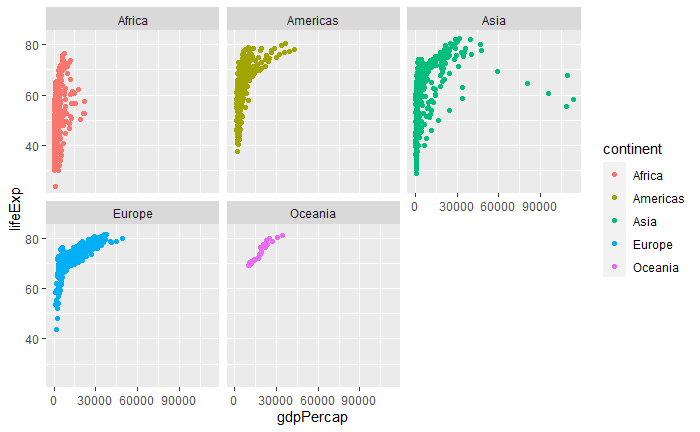

```r
p + facet_wrap(~continent)
```

The `facet_grid` function will create a grid-like plot with one variable on the x-axis and another on the y-axis.

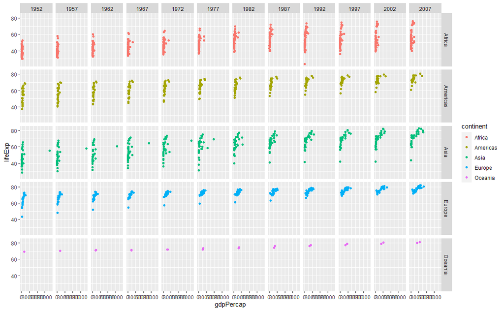

```r
p + facet_grid(continent~year)
```

We should know how to restrict the rows from the `gapminder` dataset using the `filter` function. Instead of filtering the data, creating a new data frame and constructing the data frame from these new data we can use the`%>%` operator to create the data frame on the fly and pass directly to `ggplot`. Thus we don’t have to save a new data frame or alter the original data.

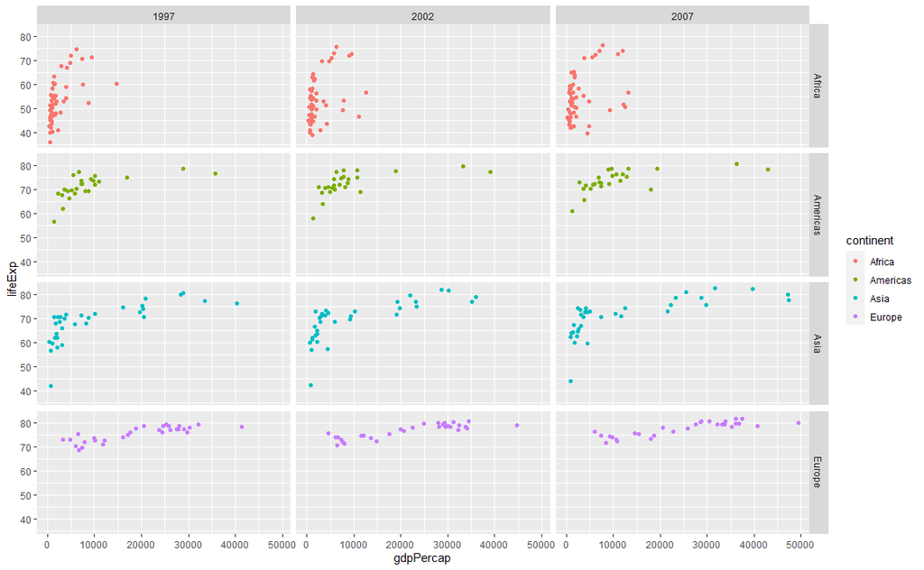

```r
filter(gapminder, continent!="Oceania", year %in% c(1997,2002,2007)) %>%
  ggplot(aes(x = gdpPercap, y=lifeExp,col=continent)) + geom_point() + facet_grid(continent~year)
```

# Summarising and grouping with dplyr

The `summarise` function can take any R function that takes a vector of values (i.e. a column from a data frame) and returns a single value. Some of the more useful functions include:

- `min` minimum value
- `max` maximum value
- `sum` sum of values
- `mean` mean value
- `sd` standard deviation
- `median` median value
- `IQR` the interquartile range
- `n_distinct` the number of distinct values
- `n` the number of observations (Note: this is a special function that doesn’t take a vector argument, i.e. column)

```r
library(dplyr)
summarise(gapminder, min(lifeExp), max(gdpPercap), mean(pop))
```

| min(lifeExp) | max(gdpPercap) | mean(pop) |
| --- | --- | --- |
| 23.599 | 113523.1 | 29601212 |

It is also possible to summarise using a function that takes more than one value, i.e. from multiple columns. For example, we could compute the correlation between year and life expectancy. Here we also assign names to the table that is produced.

```r
gapminder %>%
summarise(MinLifeExpectancy = min(lifeExp),
          MaximumGDP = max(gdpPercap),
          AveragePop = mean(pop),
          Correlation = cor(year, lifeExp))
```

| MinLifeExpectancy | MaximumGDP | AveragePop | Correlation |
| --- | --- | --- | --- |
| 23.599 | 113523.1 | 29601212 | 0.4356112 |

However, it is not particularly useful to calculate such values from the entire table as we have different continents and years. The `group_by` function allows us to split the table into different categories, and compute summary statistics for each year (for example).

```r
gapminder %>%
    group_by(year) %>%
    summarise(MinLifeExpectancy = min(lifeExp),
              MaximumGDP = max(gdpPercap),
              AveragePop = mean(pop))
```

| year | MinLifeExpectancy | MaximumGDP | AveragePop |
| --- | --- | --- | --- |
| 1952 | 28.801 | 108382.35 | 16950402 |
| 1957 | 30.332 | 113523.13 | 18763413 |
| 1962 | 31.997 | 95458.11 | 20421007 |
| 1967 | 34.020 | 80894.88 | 22658298 |
| 1972 | 35.400 | 109347.87 | 25189980 |
| 1977 | 31.220 | 59265.48 | 27676379 |
| 1982 | 38.445 | 33693.18 | 30207302 |
| 1987 | 39.906 | 31540.97 | 33038573 |
| 1992 | 23.599 | 34932.92 | 35990917 |
| 1997 | 36.087 | 41283.16 | 38839468 |

[output cut: 2 more lines]

If we want to summarise several columns we can use the convenient `summarise_all` function. However, this will return `NA` values for columns that do not contain numeric values.

```r
gapminder %>%
  group_by(continent,year) %>%
  summarise_all(mean)
```

| continent | year | country | lifeExp | pop | gdpPercap |
| --- | --- | --- | --- | --- | --- |
| Africa | 1952 | NA | 39.13550 | 4570010 | 1252.572 |
| Africa | 1957 | NA | 41.26635 | 5093033 | 1385.236 |
| Africa | 1962 | NA | 43.31944 | 5702247 | 1598.079 |
| Africa | 1967 | NA | 45.33454 | 6447875 | 2050.364 |
| Africa | 1972 | NA | 47.45094 | 7305376 | 2339.616 |
| Africa | 1977 | NA | 49.58042 | 8328097 | 2585.939 |
| Africa | 1982 | NA | 51.59287 | 9602857 | 2481.593 |
| Africa | 1987 | NA | 53.34479 | 11054502 | 2282.669 |
| Africa | 1992 | NA | 53.62958 | 12674645 | 2281.810 |
| Africa | 1997 | NA | 53.59827 | 14304480 | 2378.760 |

[output cut: 50 more lines]

The nice thing about `summarise` is that it can followed up by any of the other `dplyr` verbs that we have met so far (`select`, `filter`, `arrange`..etc). As the `country` column of the previous output containing missing values we can exclude it from further processing.

```r
gapminder %>%
  group_by(continent,year) %>%
  summarise_all(mean) %>%
  select(-country)
```

| continent | year | lifeExp | pop | gdpPercap |
| --- | --- | --- | --- | --- |
| Africa | 1952 | 39.13550 | 4570010 | 1252.572 |
| Africa | 1957 | 41.26635 | 5093033 | 1385.236 |
| Africa | 1962 | 43.31944 | 5702247 | 1598.079 |
| Africa | 1967 | 45.33454 | 6447875 | 2050.364 |
| Africa | 1972 | 47.45094 | 7305376 | 2339.616 |
| Africa | 1977 | 49.58042 | 8328097 | 2585.939 |
| Africa | 1982 | 51.59287 | 9602857 | 2481.593 |
| Africa | 1987 | 53.34479 | 11054502 | 2282.669 |
| Africa | 1992 | 53.62958 | 12674645 | 2281.810 |
| Africa | 1997 | 53.59827 | 14304480 | 2378.760 |

[output cut: 50 more lines]

Returning to the correlation between life expectancy and year, we can summarise as follows:-

```r
gapminder %>%
    group_by(country) %>%
    summarise(Correlation = cor(year , lifeExp))
```

| country | Correlation |
| --- | --- |
| Afghanistan | 0.9735051 |
| Albania | 0.9542420 |
| Algeria | 0.9925307 |
| Angola | 0.9422392 |
| Argentina | 0.9977816 |
| Australia | 0.9897716 |
| Austria | 0.9960592 |
| Bahrain | 0.9832293 |
| Bangladesh | 0.9946662 |
| Belgium | 0.9972665 |

[output cut: 132 more lines]

We can then arrange the table by the correlation to see which countries have the lowest correlation

```r
gapminder %>%
    group_by(country) %>%
    summarise(Correlation = cor(year , lifeExp)) %>%
    arrange(Correlation)
```

| country | Correlation |
| --- | --- |
| Zambia | -0.2446149 |
| Zimbabwe | -0.2371328 |
| Rwanda | -0.1309948 |
| Botswana | 0.1844543 |
| Swaziland | 0.2611721 |
| Lesotho | 0.2913011 |
| Cote d'Ivoire | 0.5323273 |
| South Africa | 0.5589890 |
| Uganda | 0.5849392 |
| Congo, Dem. Rep. | 0.5900871 |

[output cut: 132 more lines]

We can filter the results to find observations of interest

```r
gapminder %>%
    group_by(country) %>%
    summarise(Correlation = cor(year , lifeExp)) %>%
    filter(Correlation < 0)
```

| country | Correlation |
| --- | --- |
| Rwanda | -0.1309948 |
| Zambia | -0.2446149 |
| Zimbabwe | -0.2371328 |

The countries we identify could then be used as the basis for a plot.

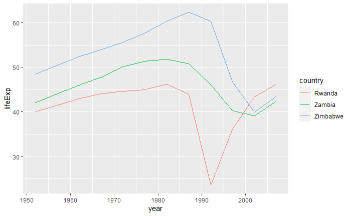

```r
library(ggplot2)
filter(gapminder, country %in% c("Rwanda","Zambia","Zimbabwe")) %>%
  ggplot(aes(x=year, y=lifeExp,col=country)) + geom_line()
```

### Exercise

- Summarise the `gapminder` data in an appropriate manner to produce a plot to show the change in average `gdpPercap` for each continent over time.
- see below for a suggestion
  - HINT: you will need to use the `geom_col` function to create the bar plot

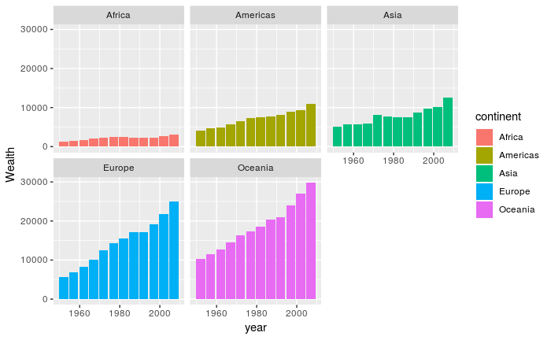

# Joining

In many real life situations, data are spread across multiple tables or spreadsheets. Usually this occurs because different types of information about a subject, e.g. a patient, are collected from different sources. It may be desirable for some analyses to combine data from two or more tables into a single data frame based on a common column, for example, an attribute that uniquely identifies the subject.

`dplyr` provides a set of join functions for combining two data frames based on matches within specified columns. For those familiar with such SQL, these operations are very similar to carrying out join operations between tables in a relational database.

As a toy example, lets consider two data frames that some results of testing whether genes A, B and C are significant in our study (gene expression, mutations, etc.)

```r
gene_results <- data.frame(Name=LETTERS[1:3], pvalue = c(0.001, 0.1,0.01))
gene_results
```

| Name | pvalue |
| --- | --- |
| A | 0.001 |
| B | 0.100 |
| C | 0.010 |

We might also have a data frame containing more data about the genes; such as which chromosome they are located on. As part of our data interpretation we might need to know where in the genome the genes are located.

```r
gene_anno <- data.frame(Name = c("A","B","D"), chromosome=c(1,1,3))
gene_anno
```

| Name | chromosome |
| --- | --- |
| A | 1 |
| B | 1 |
| D | 3 |

There are various ways in which we can join these two tables together. We will first consider the case of a “left join”.

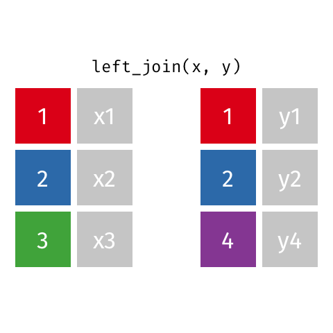

*Animated gif by Garrick Aden-Buie*

`left_join` returns all rows from the first data frame regardless of whether there is a match in the second data frame. Rows with no match are included in the resulting data frame but have `NA` values in the additional columns coming from the second data frame.

Animations to illustrate other types of join are available at https://github.com/gadenbuie/tidy-animated-verbs

```r
left_join(gene_results, gene_anno)
```

| Name | pvalue | chromosome |
| --- | --- | --- |
| A | 0.001 | 1 |
| B | 0.100 | 1 |
| C | 0.010 | NA |

```r
right_join(gene_results, gene_anno)
```

| Name | pvalue | chromosome |
| --- | --- | --- |
| A | 0.001 | 1 |
| B | 0.100 | 1 |
| D | NA | 3 |

`inner_join` only returns those rows where matches could be made

```r
inner_join(gene_results, gene_anno)
```

| Name | pvalue | chromosome |
| --- | --- | --- |
| A | 0.001 | 1 |
| B | 0.100 | 1 |

# Wrap-up

We have introduced a few of the essential packages from the R tidyverse that can help with data manipulation and visualisation.

Hopefully you will feel more confident about importing your data into R and producing some useful visualisations. You will probably have questions regarding the analysis of your own data. Some good starting points to get help are listed below.

- [tidyverse homepage](https://www.tidyverse.org/)
- [R graph gallery](https://www.r-graph-gallery.com/)

To finish the workshop we will look at the analysis of some relevant data that we can import into R and analyse with the tools from the workshop.

## Introducing the COVID-19 data

Data for global COVID-19 cases are available online from CSSE at Johns Hopkins University on their github repository.

github is an excellent way of making your code and analysis available for others to reuse and share. Private repositories with restricted access are also available. Here is a useful beginners guide.

-[Friendly github intro](https://kirstiejane.github.io/friendly-github-intro/)

R is capable of downloading files to our own machine so we can analyse them. We need to know the URL (for the COVID data we can find this from github, or use the address below) and can specify what to call the file when it is downloaded.

```r
download.file("https://raw.githubusercontent.com/CSSEGISandData/COVID-19/master/csse_covid_19_data/csse_covid_19_time_series/time_series_covid19_confirmed_global.csv",destfile = "time_series_covid19_confirmed_global.csv")
```

We can use the `read_csv` function as before to import the data and take a look. We can see the basic structure of the data is one row for each country / region and columns for cases on each day.

```r
covid <- read_csv("time_series_covid19_confirmed_global.csv")
```

```
There were 24 warnings (use warnings() to see them)
```

```r
covid
```

| Province/State | Country/Region | Lat | Long | 1/22/20 | 1/23/20 | 1/24/20 | 1/25/20 | 1/26/20 | 1/27/20 | 1/28/20 | 1/29/20 | 1/30/20 | 1/31/20 | 2/1/20 | 2/2/20 | 2/3/20 | 2/4/20 | 2/5/20 | 2/6/20 | 2/7/20 | 2/8/20 | 2/9/20 | 2/10/20 | 2/11/20 | 2/12/20 | 2/13/20 | 2/14/20 | 2/15/20 | 2/16/20 | … |
| --- | --- | --- | --- | --- | --- | --- | --- | --- | --- | --- | --- | --- | --- | --- | --- | --- | --- | --- | --- | --- | --- | --- | --- | --- | --- | --- | --- | --- | --- | --- |
| NA | Afghanistan | 33.939110 | 67.709953 | 0 | 0 | 0 | 0 | 0 | 0 | 0 | 0 | 0 | 0 | 0 | 0 | 0 | 0 | 0 | 0 | 0 | 0 | 0 | 0 | 0 | 0 | 0 | 0 | 0 | 0 | … |
| NA | Albania | 41.153300 | 20.168300 | 0 | 0 | 0 | 0 | 0 | 0 | 0 | 0 | 0 | 0 | 0 | 0 | 0 | 0 | 0 | 0 | 0 | 0 | 0 | 0 | 0 | 0 | 0 | 0 | 0 | 0 | … |
| NA | Algeria | 28.033900 | 1.659600 | 0 | 0 | 0 | 0 | 0 | 0 | 0 | 0 | 0 | 0 | 0 | 0 | 0 | 0 | 0 | 0 | 0 | 0 | 0 | 0 | 0 | 0 | 0 | 0 | 0 | 0 | … |
| NA | Andorra | 42.506300 | 1.521800 | 0 | 0 | 0 | 0 | 0 | 0 | 0 | 0 | 0 | 0 | 0 | 0 | 0 | 0 | 0 | 0 | 0 | 0 | 0 | 0 | 0 | 0 | 0 | 0 | 0 | 0 | … |
| NA | Angola | -11.202700 | 17.873900 | 0 | 0 | 0 | 0 | 0 | 0 | 0 | 0 | 0 | 0 | 0 | 0 | 0 | 0 | 0 | 0 | 0 | 0 | 0 | 0 | 0 | 0 | 0 | 0 | 0 | 0 | … |
| NA | Antigua and Barbuda | 17.060800 | -61.796400 | 0 | 0 | 0 | 0 | 0 | 0 | 0 | 0 | 0 | 0 | 0 | 0 | 0 | 0 | 0 | 0 | 0 | 0 | 0 | 0 | 0 | 0 | 0 | 0 | 0 | 0 | … |
| NA | Argentina | -38.416100 | -63.616700 | 0 | 0 | 0 | 0 | 0 | 0 | 0 | 0 | 0 | 0 | 0 | 0 | 0 | 0 | 0 | 0 | 0 | 0 | 0 | 0 | 0 | 0 | 0 | 0 | 0 | 0 | … |
| NA | Armenia | 40.069100 | 45.038200 | 0 | 0 | 0 | 0 | 0 | 0 | 0 | 0 | 0 | 0 | 0 | 0 | 0 | 0 | 0 | 0 | 0 | 0 | 0 | 0 | 0 | 0 | 0 | 0 | 0 | 0 | … |
| Australian Capital Territory | Australia | -35.473500 | 149.012400 | 0 | 0 | 0 | 0 | 0 | 0 | 0 | 0 | 0 | 0 | 0 | 0 | 0 | 0 | 0 | 0 | 0 | 0 | 0 | 0 | 0 | 0 | 0 | 0 | 0 | 0 | … |
| New South Wales | Australia | -33.868800 | 151.209300 | 0 | 0 | 0 | 0 | 3 | 4 | 4 | 4 | 4 | 4 | 4 | 4 | 4 | 4 | 4 | 4 | 4 | 4 | 4 | 4 | 4 | 4 | 4 | 4 | 4 | 4 | … |

[output cut: 256 more lines]

We can potentially join these data to `gapminder`, but it would be beneficial to have one column name in common between both files. We can `rename` the `Country/Region` column of our new data frame to match `gapminder`.

```r
covid <- read_csv("time_series_covid19_confirmed_global.csv") %>%
  rename(country = `Country/Region`)
covid
```

[output not shown]

Much of the analysis of this dataset has looked at trends over time (e.g. increasing /decreasing case numbers, comparing trajectories). As we know by now, the `ggplot2` package allows us to map columns (variables) in our dataset to aspects of the plot.

In other words, we would expect to create plots by writing code such as:-

```
ggplot(covid, aes(x = Date, y =...)) + ...
```

Unfortunately such plots are not possible with the data in it’s current format. Counts for each date are containing in a different column. What we require is a column to indicate the date, and the corresponding count in the next column. Such data arrangements are known as *long data*; whereas we have *wide* data. Fortunately we can convert between the two using the `tidyr` package (also part of tidyverse).

```r
## install tidyr if you don't already have it
install.packages("tidyr")
```

For more information on *tidy data*, and how to convert between long and wide data, see

https://r4ds.had.co.nz/tidy-data.html

```r
covid <- read_csv("time_series_covid19_confirmed_global.csv") %>%
  rename(country = `Country/Region`) %>%
  tidyr::pivot_longer(5:last_col(),names_to="Date", values_to="Cases")
covid
```

| Province/State | country | Lat | Long | Date | Cases |
| --- | --- | --- | --- | --- | --- |
| NA | Afghanistan | 33.93911 | 67.70995 | 1/22/20 | 0 |
| NA | Afghanistan | 33.93911 | 67.70995 | 1/23/20 | 0 |
| NA | Afghanistan | 33.93911 | 67.70995 | 1/24/20 | 0 |
| NA | Afghanistan | 33.93911 | 67.70995 | 1/25/20 | 0 |
| NA | Afghanistan | 33.93911 | 67.70995 | 1/26/20 | 0 |
| NA | Afghanistan | 33.93911 | 67.70995 | 1/27/20 | 0 |
| NA | Afghanistan | 33.93911 | 67.70995 | 1/28/20 | 0 |
| NA | Afghanistan | 33.93911 | 67.70995 | 1/29/20 | 0 |
| NA | Afghanistan | 33.93911 | 67.70995 | 1/30/20 | 0 |
| NA | Afghanistan | 33.93911 | 67.70995 | 1/31/20 | 0 |

[output cut: 990 more lines]

Another point to note is that the dates are not in an internationally recognised format, which could cause a problem for some visualisations that rely on date order. We can fix by explicitly converting to YYYY-MM-DD format.

```r
covid <- read_csv("time_series_covid19_confirmed_global.csv") %>%
  rename(country = `Country/Region`) %>%
  tidyr::pivot_longer(5:last_col(),names_to="Date", values_to="Cases") %>%
    mutate(Date=as.Date(Date,"%m/%d/%y"))
covid
```

| Province/State | country | Lat | Long | Date | Cases |
| --- | --- | --- | --- | --- | --- |
| NA | Afghanistan | 33.93911 | 67.70995 | 2020-01-22 | 0 |
| NA | Afghanistan | 33.93911 | 67.70995 | 2020-01-23 | 0 |
| NA | Afghanistan | 33.93911 | 67.70995 | 2020-01-24 | 0 |
| NA | Afghanistan | 33.93911 | 67.70995 | 2020-01-25 | 0 |
| NA | Afghanistan | 33.93911 | 67.70995 | 2020-01-26 | 0 |
| NA | Afghanistan | 33.93911 | 67.70995 | 2020-01-27 | 0 |
| NA | Afghanistan | 33.93911 | 67.70995 | 2020-01-28 | 0 |
| NA | Afghanistan | 33.93911 | 67.70995 | 2020-01-29 | 0 |
| NA | Afghanistan | 33.93911 | 67.70995 | 2020-01-30 | 0 |
| NA | Afghanistan | 33.93911 | 67.70995 | 2020-01-31 | 0 |

[output cut: 990 more lines]

The number of new cases per-day can also be added to the table by using the `lag` function from `dplyr`.

```r
covid <- read_csv("time_series_covid19_confirmed_global.csv") %>%
  rename(country = `Country/Region`) %>%
  tidyr::pivot_longer(5:last_col(),names_to="Date", values_to="Cases") %>%
  mutate(Date=as.Date(Date,"%m/%d/%y")) %>%
  mutate(DailyCases = Cases - dplyr::lag(Cases,default = 0))
covid
```

| Province/State | country | Lat | Long | Date | Cases | DailyCases |
| --- | --- | --- | --- | --- | --- | --- |
| NA | Afghanistan | 33.93911 | 67.70995 | 2020-01-22 | 0 | 0 |
| NA | Afghanistan | 33.93911 | 67.70995 | 2020-01-23 | 0 | 0 |
| NA | Afghanistan | 33.93911 | 67.70995 | 2020-01-24 | 0 | 0 |
| NA | Afghanistan | 33.93911 | 67.70995 | 2020-01-25 | 0 | 0 |
| NA | Afghanistan | 33.93911 | 67.70995 | 2020-01-26 | 0 | 0 |
| NA | Afghanistan | 33.93911 | 67.70995 | 2020-01-27 | 0 | 0 |
| NA | Afghanistan | 33.93911 | 67.70995 | 2020-01-28 | 0 | 0 |
| NA | Afghanistan | 33.93911 | 67.70995 | 2020-01-29 | 0 | 0 |
| NA | Afghanistan | 33.93911 | 67.70995 | 2020-01-30 | 0 | 0 |
| NA | Afghanistan | 33.93911 | 67.70995 | 2020-01-31 | 0 | 0 |

[output cut: 990 more lines]

### Exercise

What plots and summaries can you make from these data?

- Plotting the number of cases over time for certain countries
- For each continent, what countries have the highest number of cases?
- Can you normalise for population size (using 2007 population figures)?